# BCB420 A1

Nour Hassan (1009196479)

2026-02-10

# Introduction

## Paper Overview

I selected the bulk RNA-seq dataset (GEO accession: GSE298563) from a study investigating sinonasal squamous cell carcinoma (SNSCC): *Single-Nucleus Multi-Omics Reveals Hypoxia-Driven Angiogenic Programs and Their Epigenetic Control in Sinonasal Squamous Cell Carcinoma (GEO accession number: GSE298563)* (You et al., 2026). Since SNSCC is a rare malignancy with poorly characterized molecular drivers, the researchers integrated bulk RNA-seq and single-nucleus sequencing to map its molecular landscape. Their analysis revealed that one malignant cell population, TC1, exploits a hypoxia-driven angiogenic program. To investigate the drivers of this program, the researchers cultured RPMI 2650 cells (a SNSCC cell line) under normoxic (21% O₂) or hypoxic (1% O₂) conditions for 24 hours.

### Dataset Selection Reasoning

My current BCB420 research project focuses on cancer genomics. While my project examines medulloblastoma rather than carcinoma, I wanted to continue exploring cancer genomics with a bulk RNA-seq dataset. This dataset was particularly suitable because it meets several key criteria: it uses bulk RNA-seq (recommended by Professor Isserlin), compares two well-defined conditions (normoxia vs. hypoxia), and includes six samples—small enough for my system to handle while maintaining three replicates per condition for statistical rigor.

# Downloading the dataset

The dataset is available on the Gene Expression Omnibus (GEO), which can be accessed through R using the GEOquery package (Davis & Meltzer, 2007) and its accession number (GSE298563).

```r
library(GEOquery)

gse <- "GSE298563"

##### code from the identifeir mapping lecture 4

#create directory
dir.create("data", showWarnings = FALSE, recursive = TRUE)

# retrive supplementary files
GEOquery::getGEOSuppFiles(GEO = gse, baseDir = "data", makeDirectory = TRUE)

invisible(file.path("data", gse))
```

The raw counts matrix is then loaded as a table using read.table() (R Core Team, 2025) and genes with no expression across all samples are removed.

```r
counts <- read.table("data/GSE298563/GSE298563_raw_counts.txt.gz",
                     header = TRUE)

# Remove genes with zero counts in ALL samples
keep_expressed <- rowSums(counts[, -1]) > 0
counts_clean <- counts[keep_expressed, ]

counts[1:10,]
```

```
##            Gene Normoxia1 Normoxia2 Normoxia3 Hypoxia1 Hypoxia2 Hypoxia3
## 1         LIMS2        37        22        34       30       61       45
## 2         MFSD9       671       973       716      670      868      781
## 3        PLA2G6       246       364       316      434      532      608
## 4       MIR3674         0         0         0        0        0        0
## 5      MIR548AS         0         0         0        0        0        0
## 6          UCP1        10         2         3        4        1       17
## 7        FAM50B       141       201       122      195      290      223
## 8  LOC101928436         0         0         0        0        6        0
## 9      RASGEF1B        16        18        30       22       34       24
## 10        CNNM4      1238      1645      1290     1027     1392     1420
```

**Table 1.** **Raw counts data preview.** First 10 rows of the counts table. The full dataset contains 28,256 genes (rows) and 6 samples (columns): three normoxic replicates (Normoxia1-3) and three hypoxic replicates (Hypoxia1-3). Gene symbols are in the first column.

# Assessing the Data

The dataset’s matrix consisted of the raw counts data and was assessed for its number of replicates, per sample library size, and sample correlation and clustering.

## Replicates

Each condition (normoxia and hypoxia) has three biological replicates, satisfying the minimum requirement for statistical analysis. All replicates were treated as independent samples in the differential expression analysis, which used a model that explicitly accounts for within-condition variability. To assess replicate consistency, I examined sample-level correlations and clustering patterns. Expression data were visualized at the individual replicate level rather than as condition averages to preserve biological variability.

## Library Size

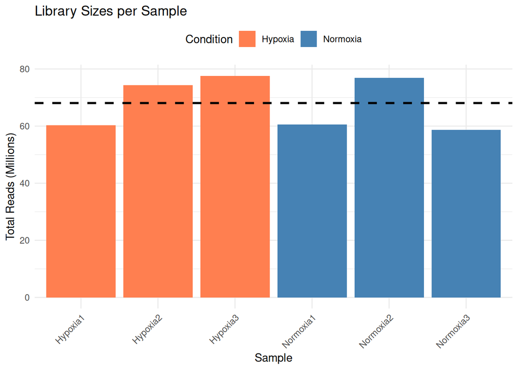

```r
#### Bar plot of library size #####
library(ggplot2)

# calculate library sizes
library_sizes <- colSums(counts[, -1])

#library size datframe
lib_size_df <- data.frame(
  Sample = names(library_sizes),
  LibrarySize_M = library_sizes / 1e6  # Convert to millions
)

# add condition
lib_size_df$Condition <- ifelse(grepl("Normoxia", lib_size_df$Sample, ignore.case = TRUE),
                            "Normoxia", "Hypoxia")


# Calculate mean
mean_lib <- mean(library_sizes)

# plot
ggplot(lib_size_df, aes(x = Sample, y = LibrarySize_M, fill = Condition)) +
  geom_bar(stat = "identity") +
  geom_hline(yintercept = mean_lib / 1e6,
             linetype = "dashed", color = "black", linewidth = 1) +
  scale_fill_manual(values = c("Normoxia" = "steelblue",
                                "Hypoxia" = "coral")) +
  theme_minimal() +
  theme(axis.text.x = element_text(angle = 45, hjust = 1),
        legend.position = "top") +
  labs(title = "Library Sizes per Sample",
       y = "Total Reads (Millions)",
       x = "Sample",
       fill = "Condition")  # Legend title
```

**Figure 1.** **Library sizes across samples**. Total reads (millions) per sample, colored by condition (orange = hypoxia, blue = normoxia). Dashed line indicates the overall mean library size.

```r
# Calculate CV (Coefficient of Variation) across samples
library_sizes <- colSums(counts[, -1])
mean_lib <- mean(library_sizes)
sd_lib <- sd(library_sizes)
cv_lib <- (sd_lib / mean_lib) * 100

cat("Mean library size:", round(mean_lib / 1e6, 2), "M reads\n")
cat("SD:", round(sd_lib / 1e6, 2), "M reads\n")
cat("CV:", round(cv_lib, 1), "%\n")
```

[output not shown]

```r
# Within-condition stats

library(dplyr)

# Check within-condition variability
lib_df <- data.frame(
  Sample = names(library_sizes),
  LibrarySize = library_sizes,
  Condition = ifelse(grepl("Hypoxia", names(library_sizes)),
                     "Hypoxia", "Normoxia")
)

lib_df %>%
  group_by(Condition) %>%
  summarise(
    `Mean in millions ` = mean(LibrarySize)/ 1e6,
    `SD in millions` = sd(LibrarySize)/ 1e6,
    `CV Percent` = (sd(LibrarySize) / mean(LibrarySize)) * 100
  )
```

```
## # A tibble: 2 × 4
##   Condition `Mean in millions ` `SD in millions` `CV Percent`
##   <chr>                   <dbl>            <dbl>        <dbl>
## 1 Hypoxia                  70.8             9.20         13.0
## 2 Normoxia                 65.4            10.0          15.3
```

**Table 2.** The following tibble (Müller & Wickham, 2025) contains the mean, standard deviation, and coefficient of variation (as a percentage) across replicates within each condition

## Sample Correlation and Clustering

Sample-to-sample Pearson correlations were consistently high across all samples (Figure 2). Within-condition correlations were similarly high, with mean correlations of 0.988 for hypoxia replicates and 0.989 for normoxia replicates. Between-condition correlations were slightly lower at 0.986. Hierarchical clustering analysis revealed clear separation between conditions, with all biological replicates clustering together by their respective treatment groups. These results demonstrate excellent replicate reproducibility and confirm that the observed variation is driven by the experimental treatment.

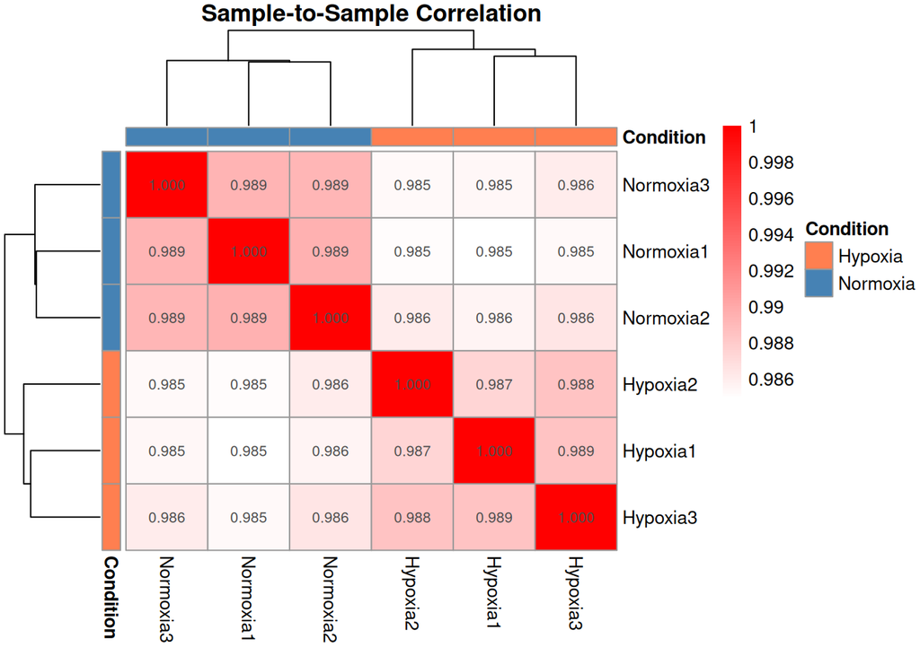

```r
library(pheatmap)
library(RColorBrewer)


log_counts <- log2(counts[, -1] + 1)
cor_matrix <- cor(log_counts, method = "pearson")

# Create condition annotation for the heatmap
annotation_col <- data.frame(
  Condition = ifelse(grepl("Hypoxia", colnames(log_counts)),
                     "Hypoxia", "Normoxia")
)
rownames(annotation_col) <- colnames(log_counts)

# Define colors for conditions
ann_colors <- list(
  Condition = c(Hypoxia = "coral", Normoxia = "steelblue")
)

# Create correlation heatmap
pheatmap(cor_matrix,
         annotation_col = annotation_col,
         annotation_row = annotation_col,
         annotation_colors = ann_colors,
         main = "Sample-to-Sample Correlation",
         color = colorRampPalette(c("white", "red"))(100),
         display_numbers = TRUE,
         number_format = "%.3f",
         fontsize = 10,
         fontsize_number = 8,
         border_color = "grey60")
```

```r
### Summary Stats ####

# Within-condition correlations
hypoxia_samples <- c("Hypoxia1", "Hypoxia2", "Hypoxia3")
normoxia_samples <- c("Normoxia1", "Normoxia2", "Normoxia3")

# Within Hypoxia
hypoxia_cors <- c(
  cor_matrix["Hypoxia1", "Hypoxia2"],
  cor_matrix["Hypoxia1", "Hypoxia3"],
  cor_matrix["Hypoxia2", "Hypoxia3"]
)

# Within Normoxia
normoxia_cors <- c(
  cor_matrix["Normoxia1", "Normoxia2"],
  cor_matrix["Normoxia1", "Normoxia3"],
  cor_matrix["Normoxia2", "Normoxia3"]
)

# Between conditions
between_cors <- as.vector(cor_matrix[hypoxia_samples, normoxia_samples])

cat("Within Hypoxia: mean =", round(mean(hypoxia_cors), 3), "\n")
```

```
## Within Hypoxia: mean = 0.988
```

```r
cat("Within Normoxia: mean =", round(mean(normoxia_cors), 3), "\n")
```

```
## Within Normoxia: mean = 0.989
```

```r
cat("Between conditions: mean =", round(mean(between_cors), 3), "\n")
```

```
## Between conditions: mean = 0.986
```

**Figure 2.** Sample correlation heatmap. Pearson correlations between all samples with hierarchical clustering dendrograms. Within-condition and between-condition mean correlations are reported below the heatmap.

# Identifier mapping

```r
# to check number of unmapped genes

length(grep("^LOC", counts$Gene))
```

[output not shown]

Most of the genes in the dataset were already mapped to their approropiate HGNC gene symbol. However,1631 are unmapped and are only represented by their NCBI identifiers. Therefore, identifier mapping was performed using the org.Hs.eg.db package (Carlson, 2025).

```r
#install package for ncbi identifier mapping if missing
if (!requireNamespace("org.Hs.eg.db", quietly = TRUE)) {
    BiocManager::install("org.Hs.eg.db")
}

library(org.Hs.eg.db)

counts_mapped <- counts

# gene IDs (mixed LOC + HGNC)
genes <- counts$Gene

# Identify LOC IDs (start with LOC)
loc_ids <- genes[grepl("^LOC", genes)]

# Extract id
entrez_ids <- sub("LOC", "", loc_ids)

# Map LOC IDs to HGNC
mapped_symbols <- mapIds(
  org.Hs.eg.db,
  keys = entrez_ids,
  column = "SYMBOL",
  keytype = "ENTREZID",
  multiVals = "first"
)

# Replace LOC IDs with mapped symbols where available
new_gene_names <- genes
for(i in seq_along(loc_ids)) {
  if(!is.na(mapped_symbols[i])) {
    new_gene_names[genes == loc_ids[i]] <- mapped_symbols[i]
  }
}

counts_mapped$Gene <- new_gene_names

counts_mapped[1:10,]
```

```
##        Gene Normoxia1 Normoxia2 Normoxia3 Hypoxia1 Hypoxia2 Hypoxia3
## 1     LIMS2        37        22        34       30       61       45
## 2     MFSD9       671       973       716      670      868      781
## 3    PLA2G6       246       364       316      434      532      608
## 4   MIR3674         0         0         0        0        0        0
## 5  MIR548AS         0         0         0        0        0        0
## 6      UCP1        10         2         3        4        1       17
## 7    FAM50B       141       201       122      195      290      223
## 8  RNPC3-DT         0         0         0        0        6        0
## 9  RASGEF1B        16        18        30       22       34       24
## 10    CNNM4      1238      1645      1290     1027     1392     1420
```

**Table 3. Mapped Raw counts data preview.** The first 10 rows of the mapped counts table are shown where some of the previously unmapped genes are mapped to their appropriate HGNC gene symbol.

```r
remain_unmapped <- length(grep("^LOC", counts_mapped$Gene))

new_mapped <- length(grep("^LOC", counts$Gene)) - length(grep("^LOC", counts_mapped$Gene))
```

This process enabled the mapping of 637 LOC identifiers to official HUGO gene symbols, while 994 genes remain unmapped due to the absence of corresponding entries in the org.Hs.eg.db annotation database. These unmapped genes were retained in the dataset as they may show differential expression between conditions.

After mapping, the dataset was checked for duplicate gene symbols (multiple rows mapping to the same gene). No duplicates were found, confirming that each gene identifier mapped to a unique HUGO symbol. If duplicates had been present, expression values would have been averaged across all rows sharing the same gene symbol to create a single consensus measurement per gene.

```r
# Check if mapping created duplicates
gene_counts <- table(counts_mapped$Gene)
duplicates <- names(gene_counts[gene_counts > 1])

cat("\n=== Duplicate Genes After Mapping ===\n")
```

```
##
## === Duplicate Genes After Mapping ===
```

```r
cat("Number of genes with duplicates:", length(duplicates), "\n")
```

```
## Number of genes with duplicates: 0
```

```r
if(length(duplicates) > 0) {
  cat("\nExample duplicates:\n")
  print(head(duplicates, 10))
}
```

# Normalization

The data compares the same cell type under different conditions. Sample-to-sample correlations are high (>0.98), and as seen in the boxplot and density plot visualizations (Figures 3 and 4), the distributions across samples are highly comparable. Therefore, the Trimmed Mean of M-values (TMM) normalization method was selected due to its underlying assumption that most genes are not differentially expressed (Robinson & Oshlack, 2010).

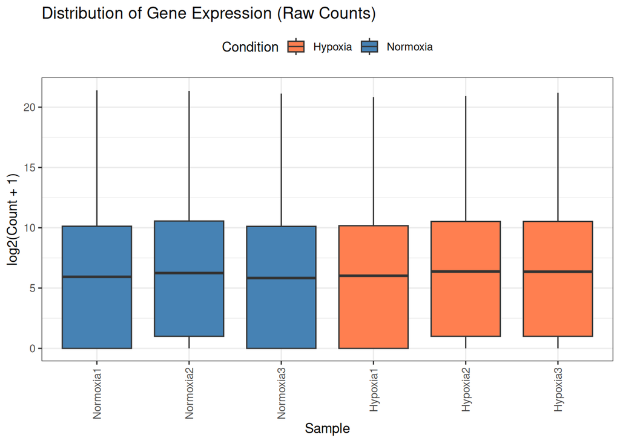

```r
# Prenormalized visualization (box plot)
#code from lecture 5 normalization



library(reshape2)
library(ggplot2)

# Extract count matrix (excluding Gene column)
count_matrix <- as.matrix(counts_mapped[, -1])
rownames(count_matrix) <- counts_mapped$Gene

# Log2 transform
log2_counts <- log2(count_matrix + 1)

# Convert to long format
df_long <- melt(log2_counts)
colnames(df_long) <- c("gene", "sample", "value")

# Add condition
df_long$Condition <- ifelse(grepl("Hypoxia", df_long$sample),
                            "Hypoxia", "Normoxia")

# Create boxplot
ggplot(df_long, aes(x = sample, y = value, fill = Condition)) +
  geom_boxplot(outlier.size = 0.2) +
  scale_fill_manual(values = c("Normoxia" = "steelblue",
                                "Hypoxia" = "coral")) +
  theme_bw() +
  theme(
    axis.text.x = element_text(angle = 90, vjust = 0.5, hjust = 1),
    legend.position = "top"
  ) +
  labs(
    title = "Distribution of Gene Expression (Raw Counts)",
    x = "Sample",
    y = "log2(Count + 1)",
    fill = "Condition"
  )
```

**Figure 3. Distribution of gene expression levels per sample.** Box plots show the distribution of log-transformed counts for each sample, colored by condition (orange = hypoxia, blue = normoxia).

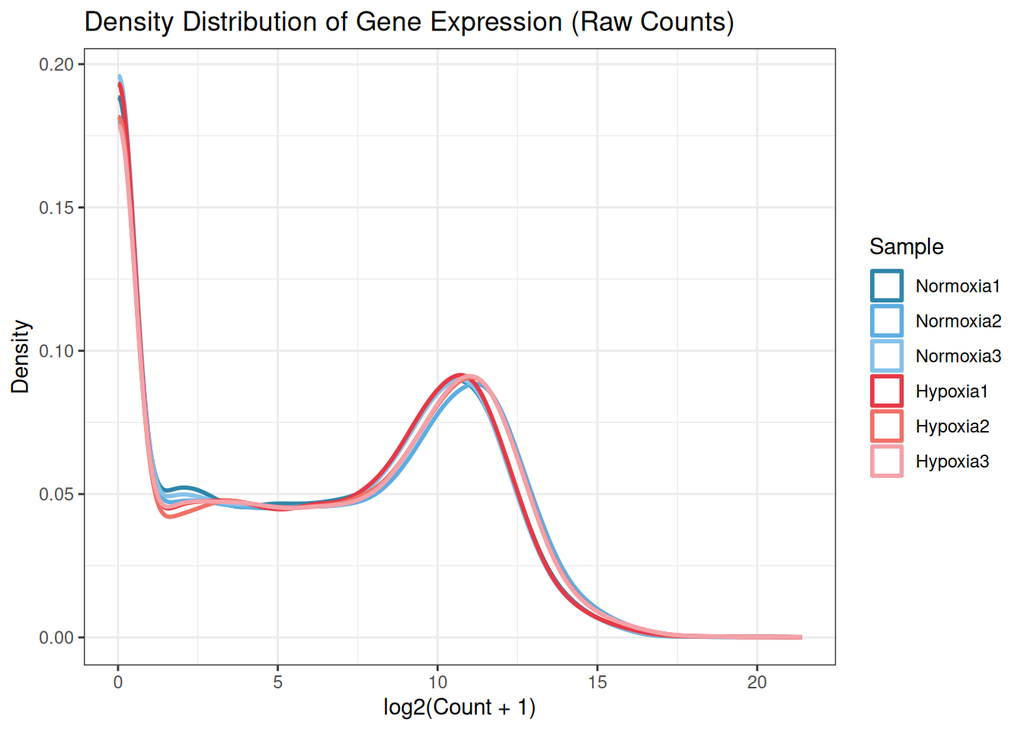

```r
#generate density plot
ggplot(df_long, aes(x = value, color = sample)) +
  geom_density(linewidth = 1) +
  scale_color_manual(values = c(
    "Normoxia1" = "#2E86AB",
    "Normoxia2" = "#5DADE2",
    "Normoxia3" = "#85C1E9",
    "Hypoxia1" = "#E63946",
    "Hypoxia2" = "#F07167",
    "Hypoxia3" = "#F4A1A8"
  )) +
  theme_bw() +
  theme(legend.position = "right") +
  labs(
    title = "Density Distribution of Gene Expression (Raw Counts)",
    x = "log2(Count + 1)",
    y = "Density",
    color = "Sample"
  )
```

**Figure 4. Distribution of gene expression levels per sample.** Density plots show the distribution of log-transformed counts for each sample, colored by sample.

## Low expression filtering

First Lowly expressed genes will be removed using edgeR’s filterbyExpr function (Chen et al., 2025) using a design matrix denoting normoxia versus hypoxia.

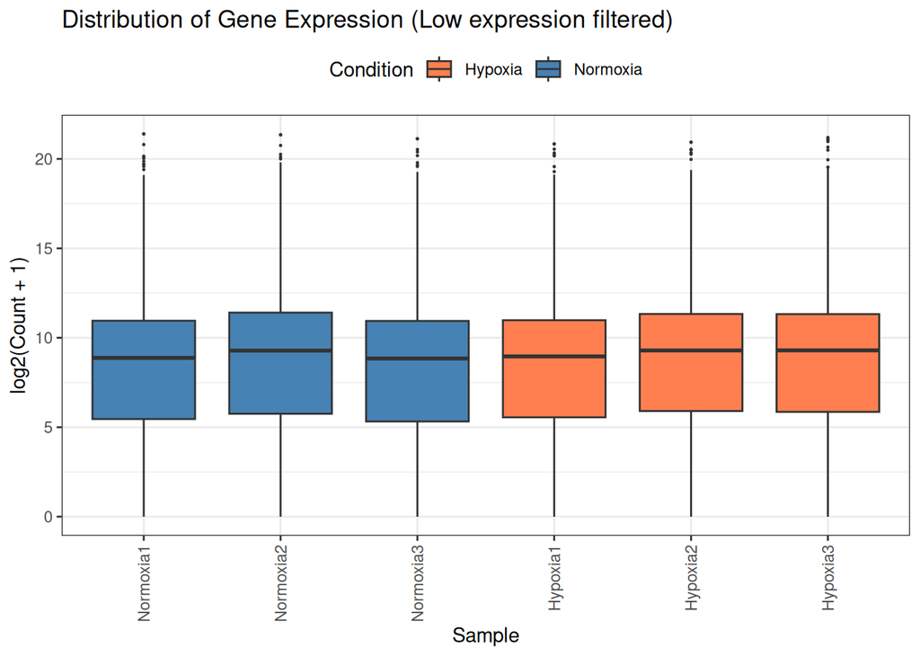

```r
#design matrix
samples <- colnames(counts_mapped)[2:ncol(counts_mapped)]
conditions <- gsub("[0-9]", "", samples)   #extract condition names with out replicate number

sample_data <- data.frame(samples = samples, conditions = conditions)

design <- model.matrix(~ 0 + conditions ,data = sample_data)
rownames(design) <- sample_data$samples
colnames(design) <- unique(conditions)

#filtering low expression
count_mat <- as.matrix(counts_mapped[2:ncol(counts_mapped)])
keep <- edgeR::filterByExpr(
  y = count_mat,
  min.count = 3,
  design = design
)

counts_filtered_withdesign <-counts_mapped[keep,]

# Extract count matrix (excluding Gene column)
count_matrix <- as.matrix(counts_filtered_withdesign[, -1])
rownames(count_matrix) <- counts_filtered_withdesign$Gene

# Log2 transform
log2_counts <- log2(count_matrix + 1)

# Convert to long format
df_long <- melt(log2_counts)
colnames(df_long) <- c("gene", "sample", "value")

# Add condition
df_long$Condition <- ifelse(grepl("Hypoxia", df_long$sample),
                            "Hypoxia", "Normoxia")

# Create boxplot
ggplot(df_long, aes(x = sample, y = value, fill = Condition)) +
  geom_boxplot(outlier.size = 0.2) +
  scale_fill_manual(values = c("Normoxia" = "steelblue",
                                "Hypoxia" = "coral")) +
  theme_bw() +
  theme(
    axis.text.x = element_text(angle = 90, vjust = 0.5, hjust = 1),
    legend.position = "top"
  ) +
  labs(
    title = "Distribution of Gene Expression (Low expression filtered)",
    x = "Sample",
    y = "log2(Count + 1)",
    fill = "Condition"
  )
```

**Figure 5. Distribution of gene expression levels post-filtering.** Box plots show the distribution of log-transformed counts post-filtering for each sample, colored by condition (orange = hypoxia, blue = normoxia).

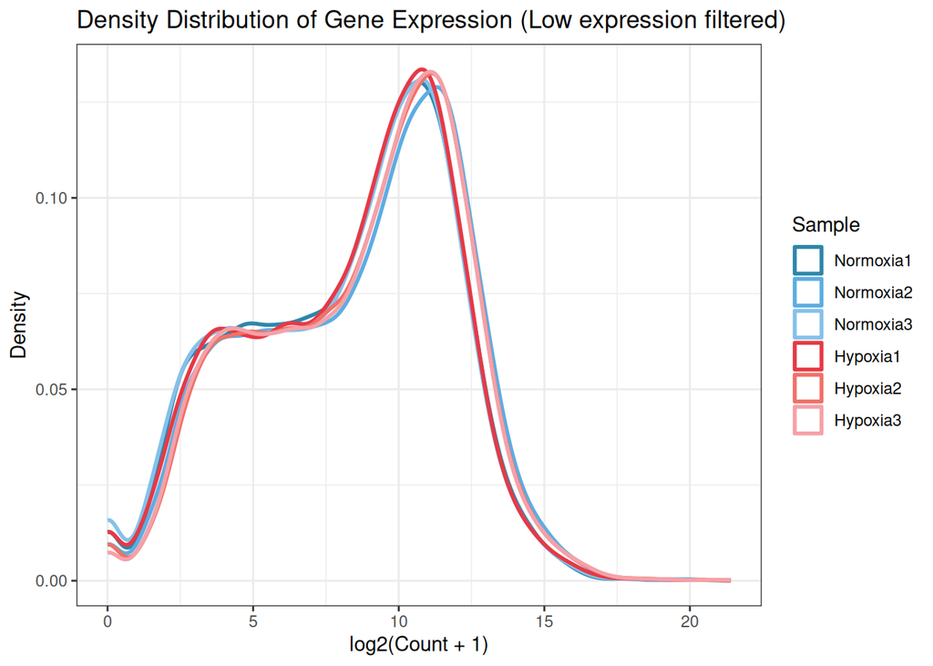

```r
#generate density plot
ggplot(df_long, aes(x = value, color = sample)) +
  geom_density(linewidth = 1) +
  scale_color_manual(values = c(
    "Normoxia1" = "#2E86AB",
    "Normoxia2" = "#5DADE2",
    "Normoxia3" = "#85C1E9",
    "Hypoxia1" = "#E63946",
    "Hypoxia2" = "#F07167",
    "Hypoxia3" = "#F4A1A8"
  )) +
  theme_bw() +
  theme(legend.position = "right") +
  labs(
    title = "Density Distribution of Gene Expression (Low expression filtered)",
    x = "log2(Count + 1)",
    y = "Density",
    color = "Sample"
  )
```

**Figure 6. Distribution of gene expression levels post-filtering per sample.** Density plots show the distribution of log-transformed counts post-filtering for each sample, colored by sample.

## TMM normalization

After filtering, TMM is normalization is performed using the edgeR pacakge (Chen et al., 2025).

```r
library(edgeR)
count_matrix <- as.matrix(counts_filtered_withdesign[, -1])
rownames(count_matrix) <- counts_filtered_withdesign$Gene

group <- factor(sample_data$conditions)

dge <- edgeR::DGEList(
  counts = count_matrix,
  group = group
)

dge <- edgeR::calcNormFactors(dge, method = "TMM")

logCPM_counts <- edgeR::cpm(dge, log = TRUE, prior.count = 1)
```

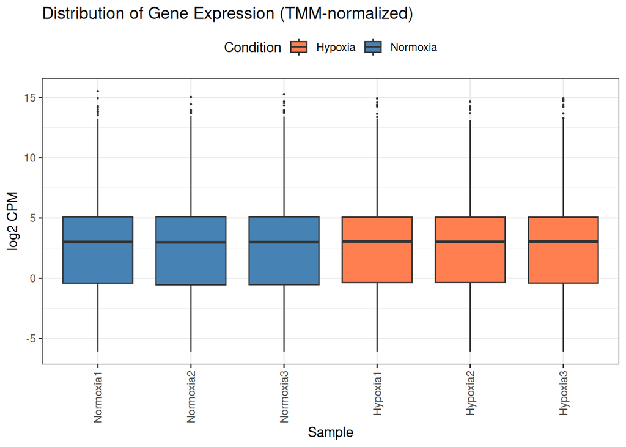

```r
#Bar plot

df_long <- reshape2::melt(logCPM_counts)
colnames(df_long) <- c("gene", "sample", "value")

df_long$Condition <- ifelse(grepl("Hypoxia", df_long$sample),
                            "Hypoxia", "Normoxia")
ggplot(df_long, aes(x = sample, y = value, fill = Condition)) +
  geom_boxplot(outlier.size = 0.2) +
  scale_fill_manual(values = c(
    "Normoxia" = "steelblue",
    "Hypoxia"  = "coral"
  )) +
  theme_bw() +
  theme(
    axis.text.x = element_text(angle = 90, vjust = 0.5, hjust = 1),
    legend.position = "top"
  ) +
  labs(
    title = "Distribution of Gene Expression (TMM-normalized)",
    x = "Sample",
    y = "log2 CPM",
    fill = "Condition"
  )
```

**Figure 7. Distribution of TMM-normalized gene expression.** Box plots show the distribution of TMM-normalized, log-transformed counts for each sample, colored by condition (orange = hypoxia, blue = normoxia).

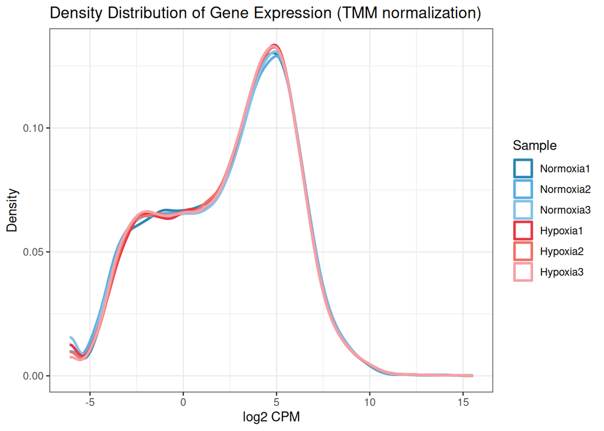

```r
#generate density plot
ggplot(df_long, aes(x = value, color = sample)) +
  geom_density(linewidth = 1) +
  scale_color_manual(values = c(
    "Normoxia1" = "#2E86AB",
    "Normoxia2" = "#5DADE2",
    "Normoxia3" = "#85C1E9",
    "Hypoxia1" = "#E63946",
    "Hypoxia2" = "#F07167",
    "Hypoxia3" = "#F4A1A8"
  )) +
  theme_bw() +
  theme(legend.position = "right") +
  labs(
    title = "Density Distribution of Gene Expression (TMM normalization)",
    x = "log2 CPM",
    y = "Density",
    color = "Sample"
  )
```

**Figure 8. Distribution of TMM-normalized gene expression.** Density plots show the distribution of TMM-normalized, log-transformed counts for each sample, colored by condition (orange = hypoxia, blue = normoxia).

## Multidimensional scaling analysis

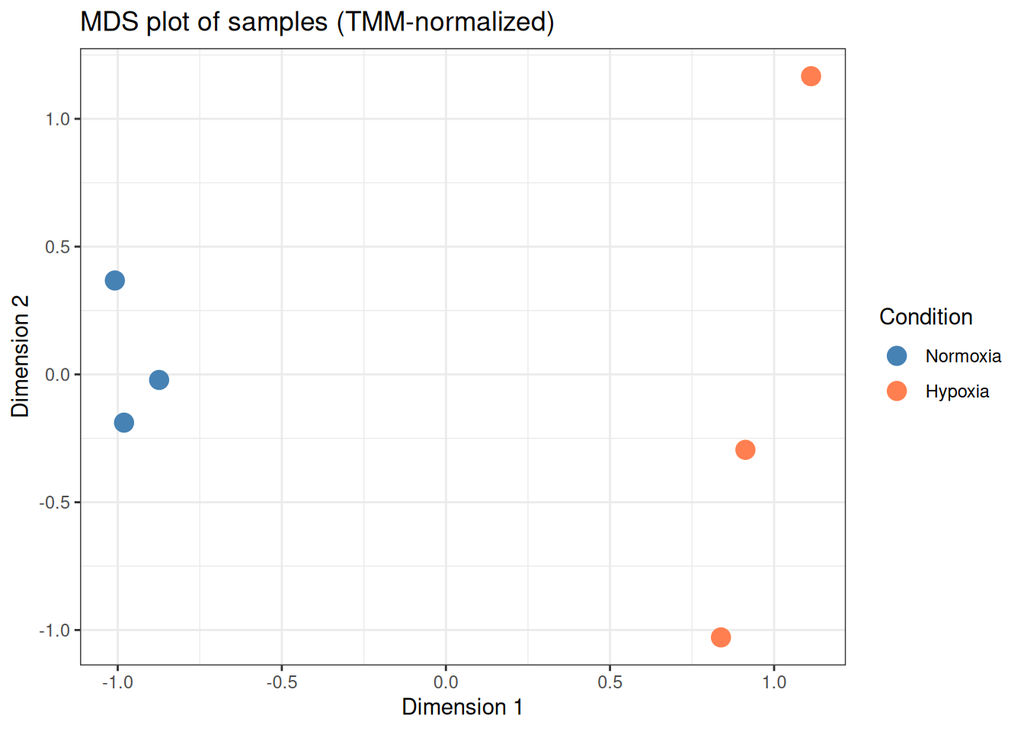

```r
#plot mds
mds <- plotMDS(dge, plot = FALSE) #edgeR function


mds_df <- data.frame(
  Sample = colnames(dge),
  Dim1 = mds$x,
  Dim2 = mds$y,
  Condition = factor(sample_data$conditions,
                     levels = c("Normoxia", "Hypoxia"))
)


ggplot(mds_df, aes(x = Dim1, y = Dim2, color = Condition)) +
  geom_point(size = 4) +
  scale_color_manual(values = c(
    "Normoxia" = "steelblue",
    "Hypoxia"  = "coral"
  )) +
  theme_bw() +
  labs(
    title = "MDS plot of samples (TMM-normalized)",
    x = "Dimension 1",
    y = "Dimension 2",
    color = "Condition"
  )
```

**Figure 9 Multidimensional scaling (MDS) plot of gene expression profiles.** Each point represents a sample, positioned based on the similarity of its expression profile to other samples. Samples are colored according to experimental condition (Hypoxia vs. Normoxia). The plot illustrates the overall variance in the dataset and highlights the clustering of samples by condition

# Differential Expression Analysis

The dataset has a conservative number of replicates per condition (3) so its statistical power is low which means it can benefit from a more conservative method such as DEseq2 (Love et al., 2014).

For differential expression analysis, raw count data were analyzed using DESeq2, which applies its own internal normalization based on median-of-ratios size factors (Love et al., 2014). Previously applied TMM normalization was used exclusively for quality control and exploratory analyses.

Differential expression analysis was performed using DESeq2 with a Wald test. Size factor normalization was applied using the median-of-ratios method, and p-values were adjusted for multiple testing using the Benjamini–Hochberg false discovery rate.

## Pvalue calculation

Differential expression analysis was performed using DESeq2, which models raw RNA-seq counts using a negative binomial generalized linear model (Love et al., 2014). For each gene, DESeq2 tests whether the log2 fold change between hypoxia and normoxia is significantly different from zero using a Wald test, producing a p-value per gene.

```r
library(DESeq2)


dds <- DESeqDataSetFromMatrix(
  countData = count_matrix,          # raw counts (genes x samples)
  colData   = sample_data,           # sample metadata
  design    = ~ conditions,           # experimental design
  tidy      = FALSE                  # counts are NOT in tidy format
)

dds <- DESeq(
  dds,
  test              = "Wald",         # Wald test for differential expression
  fitType           = "parametric",   # parametric dispersion trend fit
  betaPrior         = FALSE,          # no LFC shrinkage during model fitting
  sfType            = "ratio",        # median-of-ratios size factor estimation
  minReplicatesForReplace = 7,        # default outlier replacement threshold
  useT              = FALSE,          # normal approximation for Wald test
  quiet             = FALSE           # print progress messages
)

res <- results(
  dds,
  contrast          = c("conditions", "Hypoxia", "Normoxia"),
  alpha             = 0.05,           # FDR threshold used for padj
  pAdjustMethod     = "BH",            # Benjamini–Hochberg correction
  independentFiltering = TRUE,         # filter low-information genes
  cooksCutoff       = TRUE,            # filter genes with extreme outliers
  tidy              = FALSE
)
```

## Multiple hypothesis testing correction

P-values were corrected using the Benjamini–Hochberg (BH) false discovery rate (FDR) method, which is DESeq2’s default. RNA-seq tests thousands of genes simultaneously and BH provides a good balance between statistical power and false positive control and is the industry standard.

```r
sum(res$padj < 0.05, na.rm = TRUE)
```

[output not shown]

6088 genes passed multiple testing correction (FDR < 0.05).

## Significance thresholds and number of DE genes

The following thresholds were implemented FDR < 0.05 and |log2FC| ≥ 1 . FDR < 0.05 controls the expected proportion of false positives at 5%, which is standard for high-dimensional genomic data. |log2FC| ≥ 1 ensures that detected changes are not only statistically significant but also biologically meaningful (≥2-fold change).

```r
res_tbl <- as.data.frame(res)
sig_res <- res_tbl %>%
  filter(!is.na(padj)) %>%
  filter(padj < 0.05, abs(log2FoldChange) >= 1)

nrow(sig_res)
```

[output not shown]

498 genes were significantly differentially expressed between hypoxia and normoxia using these criteria.

## MA plot visualization

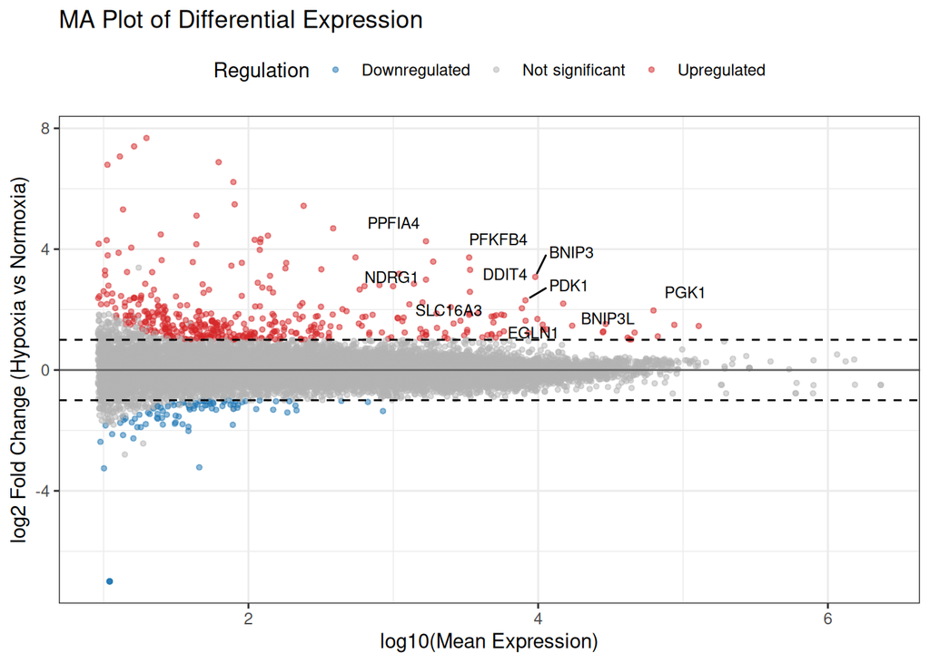

```r
library(dplyr)
library(ggrepel)
library(tibble)

res_tbl <- as.data.frame(res) %>%
  rownames_to_column(var = "gene") %>%
  filter(!is.na(padj))

# Define regulation direction
res_tbl <- res_tbl %>%
  mutate(
    regulation = case_when(
      padj < 0.05 & log2FoldChange >= 1  ~ "Upregulated",
      padj < 0.05 & log2FoldChange <= -1 ~ "Downregulated",
      TRUE                              ~ "Not significant"
    )
  )

# Select top 10 significant genes by adjusted p-value
top10 <- res_tbl %>%
  filter(regulation != "Not significant") %>%
  arrange(padj) %>%
  slice_head(n = 10)

ggplot(res_tbl, aes(x = log10(baseMean), y = log2FoldChange)) +
  geom_point(aes(color = regulation),
             alpha = 0.5, size = 1) +

  # Label top 10 genes
  geom_text_repel(
    data = top10,
    aes(label = gene),
    size = 3,
    max.overlaps = Inf,
    box.padding = 0.4,
    point.padding = 0.3
  ) +

  # Fold-change thresholds
  geom_hline(yintercept = c(-1, 1),
             linetype = "dashed", color = "black") +
  geom_hline(yintercept = 0,
             linetype = "solid", color = "grey40") +

  # Colors
  scale_color_manual(
    values = c(
      "Upregulated"     = "#D62728",  # red
      "Downregulated"   = "#1F77B4",  # blue
      "Not significant" = "grey70"
    )
  ) +

  theme_bw() +
  labs(
    title = "MA Plot of Differential Expression",
    x = "log10(Mean Expression)",
    y = "log2 Fold Change (Hypoxia vs Normoxia)",
    color = "Regulation"
  ) +
  theme(legend.position = "top")
```

**Figure 10. MA plot of differential gene expression.** Each point represents a gene, plotted by mean expression (log10 scale) and log2 fold change. Genes significantly upregulated under hypoxia (FDR < 0.05, |log2FC| ≥ 1) are shown in red, downregulated genes in blue, and non-significant genes in grey. The top 10 most significant genes are labeled.

## Top 20 Gene visualization

Top 20 differentially expressed genes (padj < 0.05, |log2FC| > 1) based on variance-stabilized expression values, showed clear separation between hypoxia and normoxia samples (refer to Figure 11).

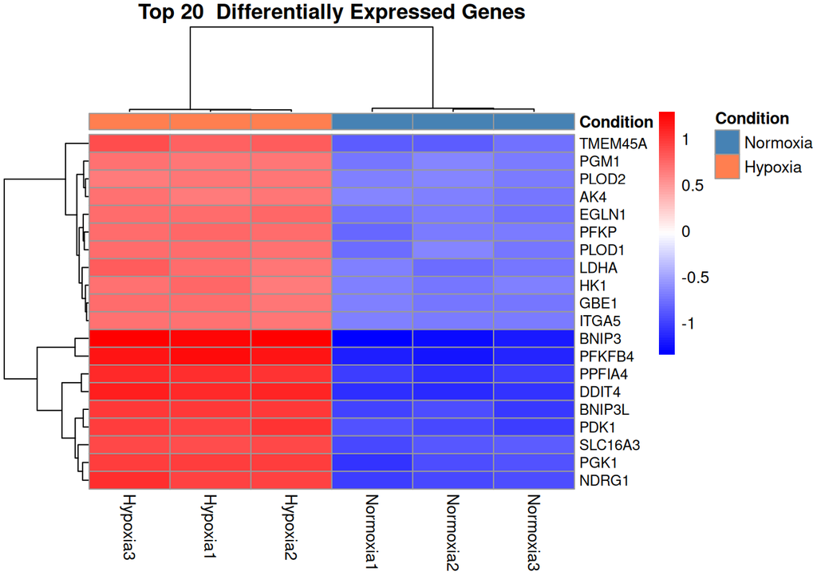

```r
sig_res$gene <- rownames(sig_res)
top_genes <- sig_res %>%
  arrange(padj) %>% #sort
  slice_head(n = 20) %>%
  pull(gene)                    #pull top 20 gene names

vsd <- vst(dds, blind = FALSE) # variance stabilized values
mat <- assay(vsd)[top_genes, ]

mat <- mat - rowMeans(mat) #centre means

annotation_col <- data.frame(
  Condition = factor(c(
    "Normoxia","Normoxia","Normoxia",
    "Hypoxia","Hypoxia","Hypoxia"
  ))
)
rownames(annotation_col) <- colnames(mat)

annotation_colors <- list(
  Condition = c(
    Normoxia = "steelblue",
    Hypoxia  = "coral"
  )
)

heat_colors <- colorRampPalette(c("blue", "white", "red"))(100)

pheatmap::pheatmap(
  mat,
  scale = "none",
  cluster_rows = TRUE,
  cluster_cols = TRUE,
  show_rownames = TRUE,
  fontsize_row = 9,
  annotation_col = annotation_col,
  annotation_colors = annotation_colors,
  color = heat_colors,
  main = "Top 20  Differentially Expressed Genes"
)
```

**Figure 11** Heatmap of the top 20 differentially expressed genes (padj < 0.05, |log2FC| > 1) based on variance-stabilized expression values, showing clear separation between hypoxia and normoxia samples.

# Final Coverage

The final dataset contains 19,690 genes (after filtering from 28,256 initial genes), with three biological replicates per condition achieving a mean sequencing depth of 68.05M reads per sample. Differential expression analysis identified 6,088 genes at FDR < 0.05, with 498 genes meeting stringent criteria (FDR < 0.05, |log2FC| ≥ 1).

```r
cat("Genes before filtering:", nrow(counts_mapped), "\n")
```

```
## Genes before filtering: 28256
```

```r
cat("Genes after filtering:", nrow(counts_filtered_withdesign), "\n")
```

```
## Genes after filtering: 19690
```

```r
cat("Genes removed:", nrow(counts_mapped) - nrow(counts_filtered_withdesign), "\n")
```

```
## Genes removed: 8566
```

```r
cat("Coverage:", mean(dge$samples$lib.size)/1e6)
```

```
## Coverage: 68.05864
```

```r
final_normalized <- reshape2::melt(dge)[,1:3]
colnames(final_normalized) <- c("gene", "sample", "counts")

# Downloading final Normalized dataset
#saveRDS(final_normalized, file = "TMM-normalized-dataset.rds")
```

# Assignment Questions

1. Why is the dataset of interest to you?

A: Dataset Selection Reasoning

2. What are the control and test conditions of the dataset?

A: Experimental Layout

3. How many samples in each of the conditions of your dataset?

A: Experimental Layout

4. Were there expression values that were not unique for specific genes? How did you handle these?

A: Idenitifier mapping

5. Were there expression values that could not be mapped to current HUGO symbols?

A: Identifier mapping

6. Were there any outliers in your dataset? How were they handled in the originating paper? How many outliers were removed?

A: Multidimensional scaling analysis

7. How did you handle replicates?

A: Replicates

8. What is the final coverage of your dataset?

A: Final Coverage

# Link to Journal Entry

The link to the Journal Entry can be found [here](https://github.com/bcb420-2026/Nour_Hassan/wiki/A1:--Dataset-selection-and-Expression-analysis)

# References

Carlson, M. (2025). *Org.hs.eg.db: Genome wide annotation for human*.

Chen, Y., Chen, L., Lun, A. T. L., Baldoni, P., & Smyth, G. K. (2025). edgeR v4: Powerful differential analysis of sequencing data with expanded functionality and improved support for small counts and larger datasets. *Nucleic Acids Research*, *53*(2), gkaf018. https://doi.org/10.1093/nar/gkaf018

Davis, S., & Meltzer, P. (2007). GEOquery: A bridge between the gene expression omnibus (GEO) and BioConductor. *Bioinformatics*, *14*, 1846–1847. https://doi.org/10.1093/bioinformatics/btm254

Isserlin, R. (2026a). *Exercise_data_normalization*. In GitHub. https://github.com/bcb420-2026/Exercise_data_normalization

Isserlin, R. (2026b). *Exercise_differential_expression*. In GitHub. https://github.com/bcb420-2026/Exercise_differential_expression

Isserlin, R. (2026c). *Exercise_identifier_mapping*. In GitHub. https://github.com/bcb420-2026/Exercise_identifier_mapping

Isserlin, R. (2026d). *Lecture 5 - identifier mapping*. In Quercus. https://q.utoronto.ca/courses/415975/files/41771201?module_item_id=7554149

Isserlin, R. (2026e). *Lecture 6 - differential expression*. In Quercus. https://q.utoronto.ca/courses/415975/files/41929669?module_item_id=7568912

Isserlin, R. (2026f). *Lecture_normalizations.html*. In Quercus. https://q.utoronto.ca/courses/415975/files/41771205?module_item_id=7568469&fd_cookie_set=1

Kolde, R. (2025). *Pheatmap: Pretty heatmaps*.

Love, M. I., Huber, W., & Anders, S. (2014). Moderated estimation of fold change and dispersion for RNA-seq data with DESeq2. *Genome Biology*, *15*, 550. https://doi.org/10.1186/s13059-014-0550-8

Müller, K., & Wickham, H. (2025). *Tibble: Simple data frames*. https://tibble.tidyverse.org/

Neuwirth, E. (2022). *RColorBrewer: ColorBrewer palettes*. https://doi.org/10.32614/CRAN.package.RColorBrewer

R Core Team. (2025). *R: A language and environment for statistical computing*. R Foundation for Statistical Computing. https://www.R-project.org/

Robinson, M. D., & Oshlack, A. (2010). A scaling normalization method for differential expression analysis of RNA-seq data. *Genome Biology*, *11*(3), R25. https://doi.org/10.1186/gb-2010-11-3-r25

Slowikowski, K. (2024). *Ggrepel: Automatically position non-overlapping text labels with ’ggplot2’*. https://doi.org/10.32614/CRAN.package.ggrepel

Wickham, H. (2007). Reshaping data with the reshape package. *Journal of Statistical Software*, *21*(12), 1–20. https://www.jstatsoft.org/v21/i12/

Wickham, H. (2016). *ggplot2: Elegant graphics for data analysis*. Springer-Verlag New York. https://ggplot2.tidyverse.org

Wickham, H., François, R., Henry, L., Müller, K., & Vaughan, D. (2023). *Dplyr: A grammar of data manipulation*. https://doi.org/10.32614/CRAN.package.dplyr

You, C., Park, J., Jang, J. Y., Noh, J., Lee, J., Kwon, G., Yu, M. S., Chung, Y.-S., Lee, S.-J., Kang, K., Park, J., Kim, J. H., & Kang, K. (2026). Single-nucleus multi-omics reveals hypoxia-driven angiogenic programs and their epigenetic control in sinonasal squamous cell carcinoma. *Advanced Science*. https://doi.org/10.1002/advs.202510302